# ST3236 — Stochastic Processes I

## Tutorial Notebook + Real-Data Case Study

This notebook is designed as a guided, proof-aware computational companion to the main ST3236 topics:

1. Introduction to stochastic processes
2. Discrete-Time Markov Chains (DTMCs)
3. Transition probability matrices
4. State classification
5. Recurrence and transience
6. First-passage, hitting, return, and stopping times
7. Stationary distributions
8. Long-run convergence and ergodicity
9. Random walks
10. Introductory Poisson-process extensions
11. **Real-data case study:** Markov-chain modelling of daily weather states using the Seattle weather dataset

The notebook mixes:

- mathematical intuition,
- small derivations,
- numerical experiments,
- simulation,
- matrix methods,
- graph-based reasoning,
- and a real downloaded dataset.

> **Note:** Computational demonstrations do not replace theorem proofs. They help build intuition and verify results numerically.

## 0. Setup

We use:

- `numpy` for probability vectors and matrix operations,
- `pandas` for real-data manipulation,
- `matplotlib` for plots,
- `networkx` for state-transition graphs,
- `scipy` for selected numerical utilities.

The real dataset is downloaded directly from a public GitHub-hosted CSV when the case study section is executed.

```python
import math
import warnings
from collections import defaultdict, Counter

import numpy as np
import pandas as pd
import matplotlib.pyplot as plt
import networkx as nx

from numpy.linalg import matrix_power, solve
from scipy.stats import poisson, expon

warnings.filterwarnings("ignore")

np.set_printoptions(precision=4, suppress=True)
pd.set_option("display.precision", 4)

RNG = np.random.default_rng(42)
```

# 1. Introduction to Stochastic Processes

A **stochastic process** is a collection of random variables

[ {X_t : t \in T} ]

indexed by time (or another index).

Examples:

- daily weather state,
- number of customers in a queue,
- machine condition,
- stock-price movement category,
- random walk position,
- number of arrivals by time (t).

Two important dimensions:

### Time index

- **Discrete time:** (T = {0,1,2,\ldots})
- **Continuous time:** (T = [0,\infty))

### State space

- finite,
- countably infinite,
- continuous.

A **sample path** is one realized sequence of values from the process.

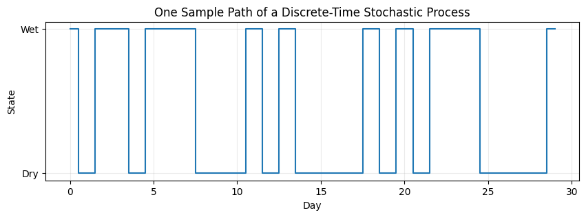

```
array([1, 0, 1, 1, 0, 1, 1, 1, 0, 0, 0, 1, 0, 1, 0, 0, 0, 0, 1, 0, 1, 0,
       1, 1, 1, 0, 0, 0, 0, 1])
```

```python
# Example stochastic process: a simple binary weather process
# 0 = Dry, 1 = Wet

sample_path = RNG.choice([0, 1], size=30, p=[0.65, 0.35])

plt.figure(figsize=(10, 3))
plt.step(range(len(sample_path)), sample_path, where="mid")
plt.yticks([0, 1], ["Dry", "Wet"])
plt.xlabel("Day")
plt.ylabel("State")
plt.title("One Sample Path of a Discrete-Time Stochastic Process")
plt.grid(alpha=0.25)
plt.show()

sample_path
```

## Dependence matters

If (X_1,\ldots,X_n) are independent, then knowledge of the past tells us nothing about the future.

A stochastic process is often more interesting because values are **dependent over time**.

For example, weather tomorrow may depend strongly on weather today.

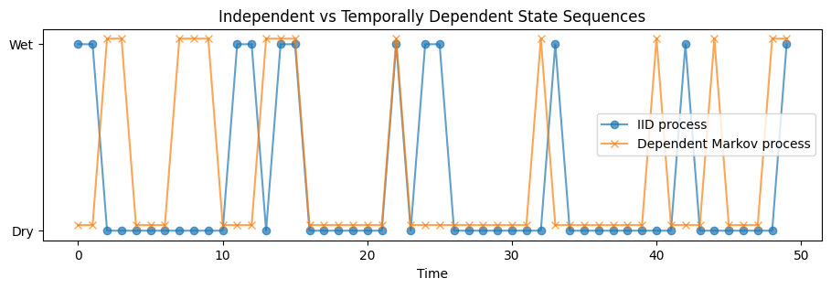

```python
# Compare independent draws versus a dependent two-state process

n = 100

iid_states = RNG.choice([0, 1], size=n, p=[0.7, 0.3])

P_demo = np.array([
    [0.85, 0.15],  # dry -> dry/wet
    [0.40, 0.60],  # wet -> dry/wet
])

markov_states = np.empty(n, dtype=int)
markov_states[0] = 0

for t in range(1, n):
    markov_states[t] = RNG.choice([0, 1], p=P_demo[markov_states[t-1]])

fig, ax = plt.subplots(figsize=(11, 3))
ax.plot(iid_states[:50], marker="o", alpha=0.7, label="IID process")
ax.plot(markov_states[:50] + 0.03, marker="x", alpha=0.7, label="Dependent Markov process")
ax.set_yticks([0, 1])
ax.set_yticklabels(["Dry", "Wet"])
ax.set_xlabel("Time")
ax.legend()
ax.set_title("Independent vs Temporally Dependent State Sequences")
plt.show()
```

# 2. Discrete-Time Markov Chains

A discrete-time process ({X_n}) is a **Markov chain** if

# [ P(X_{n+1}=j \mid X_n=i,X_{n-1},\ldots,X_0)

P(X_{n+1}=j \mid X_n=i). ]

The future depends on the **current state**, not the full history.

For a time-homogeneous Markov chain,

[ P(X_{n+1}=j \mid X_n=i)=p_{ij} ]

does not depend on (n).

The numbers (p_{ij}) form the **transition matrix**

[ P=(p_{ij}). ]

```python
states = ["Sunny", "Cloudy", "Rainy"]

P = np.array([
    [0.70, 0.20, 0.10],
    [0.30, 0.50, 0.20],
    [0.20, 0.30, 0.50],
])

P_df = pd.DataFrame(P, index=states, columns=states)
P_df
```

|  | Sunny | Cloudy | Rainy |
| --- | --- | --- | --- |
| Sunny | 0.7 | 0.2 | 0.1 |
| Cloudy | 0.3 | 0.5 | 0.2 |
| Rainy | 0.2 | 0.3 | 0.5 |

Every row must sum to one:

[ \sum_j p_{ij}=1. ]

```python
row_sums = P.sum(axis=1)
row_sums
```

```
array([1., 1., 1.])
```

## Simulating a Markov chain

Simulation algorithm:

1. Start in state (X_0).
2. Look at row (X_t) of (P).
3. Sample (X_{t+1}) using that row as a categorical distribution.
4. Repeat.

```python
def simulate_markov_chain(P, start_state, n_steps, rng=None):
    rng = np.random.default_rng() if rng is None else rng
    path = [start_state]

    for _ in range(n_steps):
        current = path[-1]
        nxt = rng.choice(P.shape[0], p=P[current])
        path.append(nxt)

    return np.array(path)

path = simulate_markov_chain(P, start_state=0, n_steps=50, rng=RNG)

pd.Series([states[i] for i in path]).head(20)
```

```
0      Sunny
1      Sunny
2      Sunny
3      Sunny
4      Rainy
5      Rainy
6      Rainy
7      Rainy
8     Cloudy
9     Cloudy
10     Sunny
11     Sunny
12    Cloudy
13    Cloudy
14     Sunny
15     Sunny
16     Sunny
17    Cloudy
18    Cloudy
19    Cloudy
dtype: object
```

# 3. Transition Probability Matrices and (n)-Step Transitions

The one-step probability is

[ P(X_{n+1}=j\mid X_n=i)=p_{ij}. ]

For two steps,

# [ p_{ij}^{(2)}

\sum_k p_{ik}p_{kj}, ]

which is exactly matrix multiplication:

[ P^{(2)} = P^2. ]

More generally,

[ P^{(n)} = P^n. ]

This is the matrix form of the **Chapman–Kolmogorov equation**.

```python
P2 = matrix_power(P, 2)
P5 = matrix_power(P, 5)

print("P^2")
display(pd.DataFrame(P2, index=states, columns=states))

print("P^5")
display(pd.DataFrame(P5, index=states, columns=states))
```

```
P^2
```

|  | Sunny | Cloudy | Rainy |
| --- | --- | --- | --- |
| Sunny | 0.57 | 0.27 | 0.16 |
| Cloudy | 0.40 | 0.37 | 0.23 |
| Rainy | 0.33 | 0.34 | 0.33 |

```
P^5
```

|  | Sunny | Cloudy | Rainy |
| --- | --- | --- | --- |
| Sunny | 0.4737 | 0.3131 | 0.2133 |
| Cloudy | 0.4583 | 0.3194 | 0.2223 |
| Rainy | 0.4492 | 0.3221 | 0.2287 |

Suppose today is Sunny. The probability of Rainy weather in 5 days is

[ (P^5)_{\text{Sunny,Rainy}}. ]

```python
sunny_idx = states.index("Sunny")
rainy_idx = states.index("Rainy")

prob_rainy_in_5 = P5[sunny_idx, rainy_idx]
prob_rainy_in_5
```

```
0.21326
```

## Distribution propagation

If the initial row-vector distribution is

[ \mu_0, ]

then after (n) steps,

[ \mu_n = \mu_0P^n. ]

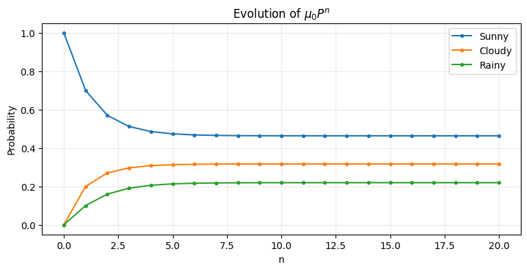

```python
mu0 = np.array([1.0, 0.0, 0.0])  # certainly Sunny initially

trajectory = []

for n in range(21):
    mu_n = mu0 @ matrix_power(P, n)
    trajectory.append(mu_n)

trajectory = np.array(trajectory)

plt.figure(figsize=(9, 4))
for i, state in enumerate(states):
    plt.plot(trajectory[:, i], marker="o", markersize=3, label=state)

plt.xlabel("n")
plt.ylabel("Probability")
plt.title(r"Evolution of $\mu_0P^n$")
plt.legend()
plt.grid(alpha=0.25)
plt.show()
```

# 4. Classification of States

Important relations:

### Accessibility

State (j) is accessible from (i) if

[ p_{ij}^{(n)}>0 ]

for some (n\ge 0).

Write

[ i\to j. ]

### Communication

States (i,j) communicate if

[ i\to j \quad\text{and}\quad j\to i. ]

Write

[ i\leftrightarrow j. ]

Communication partitions the state space into **communicating classes**.

### Irreducibility

A chain is irreducible if every pair of states communicates.

### Periodicity

The period of state (i) is

[ d(i)=\gcd{n\ge1:p_{ii}^{(n)}>0}. ]

A state is **aperiodic** if (d(i)=1).

```python
def adjacency_from_transition(P, tol=1e-12):
    return (P > tol).astype(int)

A = adjacency_from_transition(P)
A
```

```
array([[1, 1, 1],
       [1, 1, 1],
       [1, 1, 1]])
```

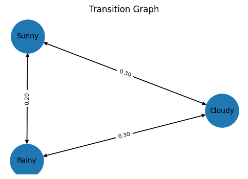

```
[{'Cloudy', 'Rainy', 'Sunny'}]
```

```python
G = nx.DiGraph()

for i, s in enumerate(states):
    G.add_node(s)

for i, s1 in enumerate(states):
    for j, s2 in enumerate(states):
        if P[i, j] > 0:
            G.add_edge(s1, s2, weight=P[i, j])

plt.figure(figsize=(6, 4))
pos = nx.spring_layout(G, seed=42)
nx.draw_networkx(G, pos, arrows=True, node_size=2200, font_size=10)
edge_labels = {(u, v): f"{d['weight']:.2f}" for u, v, d in G.edges(data=True)}
nx.draw_networkx_edge_labels(G, pos, edge_labels=edge_labels, font_size=8)
plt.axis("off")
plt.title("Transition Graph")
plt.show()

list(nx.strongly_connected_components(G))
```

Because all three states belong to one strongly connected component, this example chain is **irreducible**.

## Computing periods numerically for a finite chain

For teaching purposes, we can inspect values of (n) such that

[ (P^n)_{ii}>0. ]

For a rigorous proof, one normally reasons structurally from the transition graph.

```python
from math import gcd
from functools import reduce

def approximate_state_period(P, state_idx, max_n=30, tol=1e-12):
    return_times = []

    for n in range(1, max_n + 1):
        if matrix_power(P, n)[state_idx, state_idx] > tol:
            return_times.append(n)

    if not return_times:
        return None, []

    return reduce(gcd, return_times), return_times

for i, s in enumerate(states):
    period, times = approximate_state_period(P, i)
    print(s, "period =", period, "| detected return lengths =", times[:12])
```

```
Sunny period = 1 | detected return lengths = [1, 2, 3, 4, 5, 6, 7, 8, 9, 10, 11, 12]
Cloudy period = 1 | detected return lengths = [1, 2, 3, 4, 5, 6, 7, 8, 9, 10, 11, 12]
Rainy period = 1 | detected return lengths = [1, 2, 3, 4, 5, 6, 7, 8, 9, 10, 11, 12]
```

# 5. Recurrence and Transience

A state is **recurrent** if, starting from it, the process returns to that state with probability 1.

Otherwise it is **transient**.

For finite irreducible Markov chains:

> Every state is positive recurrent.

That is a theorem, so the current finite irreducible weather chain is recurrent in every state.

To see recurrence/transience more clearly, consider a chain with an absorbing state.

```python
P_absorb = np.array([
    [0.5, 0.5, 0.0],
    [0.0, 0.6, 0.4],
    [0.0, 0.0, 1.0],
])

abs_states = ["A", "B", "C(absorbing)"]

pd.DataFrame(P_absorb, index=abs_states, columns=abs_states)
```

|  | A | B | C(absorbing) |
| --- | --- | --- | --- |
| A | 0.5 | 0.5 | 0.0 |
| B | 0.0 | 0.6 | 0.4 |
| C(absorbing) | 0.0 | 0.0 | 1.0 |

Here state (C) is absorbing because

[ p_{CC}=1. ]

States (A) and (B) are transient: eventually probability mass flows toward (C).

```python
mu0 = np.array([1.0, 0.0, 0.0])

rows = []
for n in [0, 1, 2, 5, 10, 20]:
    rows.append([n, *(mu0 @ matrix_power(P_absorb, n))])

pd.DataFrame(rows, columns=["n", *abs_states])
```

|  | n | A | B | C(absorbing) |
| --- | --- | --- | --- | --- |
| 0 | 0 | 1.0000e+00 | 0.0000 | 0.0000 |
| 1 | 1 | 5.0000e-01 | 0.5000 | 0.0000 |
| 2 | 2 | 2.5000e-01 | 0.5500 | 0.2000 |
| 3 | 5 | 3.1250e-02 | 0.2326 | 0.7362 |
| 4 | 10 | 9.7656e-04 | 0.0254 | 0.9737 |
| 5 | 20 | 9.5367e-07 | 0.0002 | 0.9998 |

# 6. First Passage, Hitting Times, Return Times, and Stopping Times

For target state (j), define the **hitting time**

[ T_j=\inf{n\ge0:X_n=j}. ]

If we require a return after leaving the initial time,

[ T_i^+=\inf{n\ge1:X_n=i}. ]

A powerful technique is **first-step analysis**.

Suppose (h_i) is the probability of eventually reaching target state (j).

For non-target states,

[ h_i=\sum_k p_{ik}h_k. ]

Boundary condition:

[ h_j=1. ]

Expected hitting times satisfy a similar recursion:

[ m_i=1+\sum_kp_{ik}m_k, \quad i\neq j, ]

with

[ m_j=0. ]

```python
def expected_hitting_times(P, target):
    n = P.shape[0]
    non_target = [i for i in range(n) if i != target]

    Q = P[np.ix_(non_target, non_target)]

    # m = 1 + Qm  => (I-Q)m = 1
    m_non = solve(np.eye(len(Q)) - Q, np.ones(len(Q)))

    m = np.zeros(n)
    m[non_target] = m_non
    m[target] = 0.0
    return m

target = 2  # Rainy
m = expected_hitting_times(P, target)

pd.Series(m, index=states, name="Expected steps to first hit Rainy")
```

```
Sunny     7.7778
Cloudy    6.6667
Rainy     0.0000
Name: Expected steps to first hit Rainy, dtype: float64
```

## Monte Carlo verification

```python
def simulate_hitting_time(P, start, target, n_sim=20_000, max_steps=10_000, rng=None):
    rng = np.random.default_rng() if rng is None else rng
    times = []

    for _ in range(n_sim):
        state = start

        if state == target:
            times.append(0)
            continue

        for t in range(1, max_steps + 1):
            state = rng.choice(P.shape[0], p=P[state])
            if state == target:
                times.append(t)
                break

    return np.array(times)

sim_times = simulate_hitting_time(P, start=0, target=2, rng=RNG)

print("Analytical E[T_Rainy | Sunny] =", m[0])
print("Monte Carlo estimate            =", sim_times.mean())
```

```
Analytical E[T_Rainy | Sunny] = 7.777777777777776
Monte Carlo estimate            = 7.76095
```

## Absorbing-chain fundamental matrix

If the transition matrix is arranged as

[ P= \begin{bmatrix} Q & R\\ 0 & I \end{bmatrix}, ]

then

[ N=(I-Q)^{-1} ]

is called the **fundamental matrix**.

Interpretation:

[ N_{ij} ]

is the expected number of visits to transient state (j), starting from transient state (i), before absorption.

Expected absorption time:

[ t=N\mathbf{1}. ]

```python
Q = P_absorb[:2, :2]
R = P_absorb[:2, 2:]

N = np.linalg.inv(np.eye(Q.shape[0]) - Q)

expected_time_to_absorption = N @ np.ones(Q.shape[0])
absorption_probabilities = N @ R

print("Fundamental matrix N")
display(pd.DataFrame(N, index=["A", "B"], columns=["A", "B"]))

print("Expected time to absorption")
display(pd.Series(expected_time_to_absorption, index=["A", "B"]))

print("Absorption probabilities")
display(pd.DataFrame(absorption_probabilities, index=["A", "B"], columns=["C"]))
```

```
Fundamental matrix N
```

|  | A | B |
| --- | --- | --- |
| A | 2.0 | 2.5 |
| B | 0.0 | 2.5 |

```
Expected time to absorption
```

```
A    4.5
B    2.5
dtype: float64
```

```
Absorption probabilities
```

|  | C |
| --- | --- |
| A | 1.0 |
| B | 1.0 |

# 7. Stationary Distributions

A probability vector (\pi) is stationary if

[ \pi P=\pi, ]

and

[ \sum_i\pi_i=1. ]

Equivalently, (\pi^\top) is an eigenvector of (P^\top) corresponding to eigenvalue (1).

```python
def stationary_distribution(P):
    eigvals, eigvecs = np.linalg.eig(P.T)
    idx = np.argmin(np.abs(eigvals - 1))
    vec = np.real(eigvecs[:, idx])
    vec = vec / vec.sum()
    return vec

pi = stationary_distribution(P)

pd.Series(pi, index=states, name="stationary_probability")
```

```
Sunny     0.4634
Cloudy    0.3171
Rainy     0.2195
Name: stationary_probability, dtype: float64
```

```python
print("pi @ P =", pi @ P)
print("pi     =", pi)
print("sum(pi) =", pi.sum())
```

```
pi @ P = [0.4634 0.3171 0.2195]
pi     = [0.4634 0.3171 0.2195]
sum(pi) = 1.0
```

For an irreducible positive recurrent chain, the stationary distribution is unique.

For a finite irreducible chain, positive recurrence is automatic.

# 8. Convergence and Long-Run Behaviour

For many finite irreducible **aperiodic** chains,

[ P^n \to \begin{bmatrix} \pi\\ \pi\\ \vdots \end{bmatrix}. ]

Thus the distribution of (X_n) converges to (\pi), regardless of the starting state.

```python
powers = [1, 2, 5, 10, 25, 50]

for n in powers:
    print(f"\nP^{n}")
    display(pd.DataFrame(matrix_power(P, n), index=states, columns=states))
```

```
P^1
```

|  | Sunny | Cloudy | Rainy |
| --- | --- | --- | --- |
| Sunny | 0.7 | 0.2 | 0.1 |
| Cloudy | 0.3 | 0.5 | 0.2 |
| Rainy | 0.2 | 0.3 | 0.5 |

```
P^2
```

|  | Sunny | Cloudy | Rainy |
| --- | --- | --- | --- |
| Sunny | 0.57 | 0.27 | 0.16 |
| Cloudy | 0.40 | 0.37 | 0.23 |
| Rainy | 0.33 | 0.34 | 0.33 |

```
P^5
```

|  | Sunny | Cloudy | Rainy |
| --- | --- | --- | --- |
| Sunny | 0.4737 | 0.3131 | 0.2133 |
| Cloudy | 0.4583 | 0.3194 | 0.2223 |
| Rainy | 0.4492 | 0.3221 | 0.2287 |

```
P^10
```

|  | Sunny | Cloudy | Rainy |
| --- | --- | --- | --- |
| Sunny | 0.4636 | 0.3170 | 0.2194 |
| Cloudy | 0.4633 | 0.3171 | 0.2196 |
| Rainy | 0.4631 | 0.3172 | 0.2197 |

```
P^25
```

|  | Sunny | Cloudy | Rainy |
| --- | --- | --- | --- |
| Sunny | 0.4634 | 0.3171 | 0.2195 |
| Cloudy | 0.4634 | 0.3171 | 0.2195 |
| Rainy | 0.4634 | 0.3171 | 0.2195 |

```
P^50
```

|  | Sunny | Cloudy | Rainy |
| --- | --- | --- | --- |
| Sunny | 0.4634 | 0.3171 | 0.2195 |
| Cloudy | 0.4634 | 0.3171 | 0.2195 |
| Rainy | 0.4634 | 0.3171 | 0.2195 |

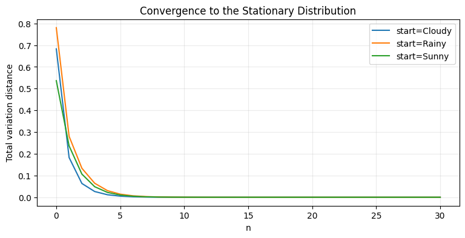

```python
# Quantify convergence using total variation distance

def total_variation(p, q):
    return 0.5 * np.abs(p - q).sum()

start_distributions = np.eye(len(states))

records = []

for start_idx, mu0 in enumerate(start_distributions):
    for n in range(31):
        mu_n = mu0 @ matrix_power(P, n)
        records.append({
            "start": states[start_idx],
            "n": n,
            "tv_distance_to_pi": total_variation(mu_n, pi),
        })

conv_df = pd.DataFrame(records)

plt.figure(figsize=(9, 4))
for state, grp in conv_df.groupby("start"):
    plt.plot(grp["n"], grp["tv_distance_to_pi"], label=f"start={state}")

plt.xlabel("n")
plt.ylabel("Total variation distance")
plt.title("Convergence to the Stationary Distribution")
plt.legend()
plt.grid(alpha=0.25)
plt.show()
```

## Ergodic interpretation

Under suitable conditions,

[ \frac1N\sum_{t=1}^{N}\mathbf{1}{X_t=i} \to \pi_i. ]

That means long-run empirical proportions approach stationary probabilities.

```python
long_path = simulate_markov_chain(P, start_state=0, n_steps=100_000, rng=RNG)

empirical_freq = np.bincount(long_path, minlength=len(states))
empirical_freq = empirical_freq / empirical_freq.sum()

comparison = pd.DataFrame({
    "stationary": pi,
    "empirical_100k_steps": empirical_freq,
}, index=states)

comparison
```

|  | stationary | empirical_100k_steps |
| --- | --- | --- |
| Sunny | 0.4634 | 0.4638 |
| Cloudy | 0.3171 | 0.3163 |
| Rainy | 0.2195 | 0.2200 |

# 9. Random Walks

The simplest one-dimensional random walk is

[ S_n = \sum_{k=1}^{n}Y_k, ]

where

[ Y_k= \begin{cases} +1 & \text{with probability } p,\\ -1 & \text{with probability } 1-p. \end{cases} ]

For (p=1/2), it is a **symmetric random walk**.

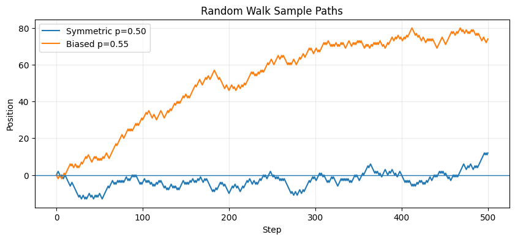

```python
def random_walk(n_steps=500, p=0.5, start=0, rng=None):
    rng = np.random.default_rng() if rng is None else rng
    increments = rng.choice([-1, 1], size=n_steps, p=[1-p, p])
    positions = np.r_[start, start + np.cumsum(increments)]
    return positions

rw_sym = random_walk(500, p=0.5, rng=RNG)
rw_bias = random_walk(500, p=0.55, rng=RNG)

plt.figure(figsize=(10, 4))
plt.plot(rw_sym, label="Symmetric p=0.50")
plt.plot(rw_bias, label="Biased p=0.55")
plt.axhline(0, linewidth=1)
plt.xlabel("Step")
plt.ylabel("Position")
plt.title("Random Walk Sample Paths")
plt.legend()
plt.grid(alpha=0.25)
plt.show()
```

## Gambler's Ruin

Let the walk evolve on

[ {0,1,\ldots,N} ]

with absorbing boundaries at (0) and (N).

Starting from (i), we ask:

> What is the probability of reaching (N) before (0)?

For (p=q=1/2),

[ P_i(\text{hit }N\text{ before }0)=\frac{i}{N}. ]

For (p\neq q),

# [ P_i

\frac{1-(q/p)^i} {1-(q/p)^N}. ]

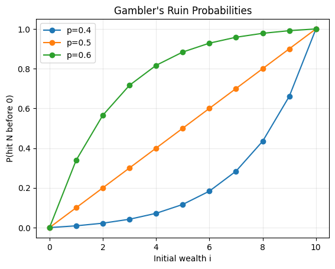

```python
def gambler_ruin_prob(i, N, p):
    q = 1 - p
    if np.isclose(p, q):
        return i / N
    return (1 - (q/p)**i) / (1 - (q/p)**N)

for p in [0.4, 0.5, 0.6]:
    probs = [gambler_ruin_prob(i, 10, p) for i in range(11)]
    plt.plot(range(11), probs, marker="o", label=f"p={p}")

plt.xlabel("Initial wealth i")
plt.ylabel("P(hit N before 0)")
plt.title("Gambler's Ruin Probabilities")
plt.legend()
plt.grid(alpha=0.25)
plt.show()
```

# 10. Introductory Poisson Processes

A Poisson process ({N(t)}) with rate (\lambda>0) satisfies

[ N(t)\sim \operatorname{Poisson}(\lambda t). ]

Therefore

# [ P(N(t)=k)

e^{-\lambda t} \frac{(\lambda t)^k}{k!}. ]

Its inter-arrival times are iid exponential random variables:

[ T_i\sim \operatorname{Exp}(\lambda). ]

The exponential distribution is memoryless:

[ P(T>s+t\mid T>s)=P(T>t). ]

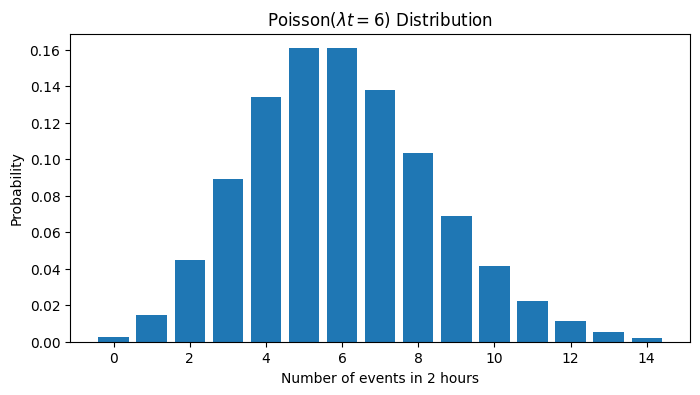

```python
lam = 3.0   # average 3 events/hour
t = 2.0

k_values = np.arange(0, 15)
pmf = poisson.pmf(k_values, mu=lam*t)

plt.figure(figsize=(8, 4))
plt.bar(k_values, pmf)
plt.xlabel("Number of events in 2 hours")
plt.ylabel("Probability")
plt.title(r"Poisson($\lambda t=6$) Distribution")
plt.show()
```

```python
# Simulate Poisson-process event times through exponential inter-arrivals

lam = 3.0
inter_arrivals = RNG.exponential(scale=1/lam, size=30)
arrival_times = np.cumsum(inter_arrivals)

arrival_times[:10]
```

```
array([0.0803, 0.082 , 0.7689, 0.9587, 1.026 , 1.0292, 1.0944, 1.3479,
       1.5456, 2.3398])
```

## Memoryless-property numerical check

For exponential (T),

# \frac{P(T>s+t)}{P(T>s)}

P(T>t). ]

```python
lam = 2.0
s = 1.0
t = 0.75

lhs = expon.sf(s+t, scale=1/lam) / expon.sf(s, scale=1/lam)
rhs = expon.sf(t, scale=1/lam)

lhs, rhs
```

```
(0.22313016014842982, 0.22313016014842982)
```

# 11. Real-Data Case Study

# Modelling Daily Weather as a Markov Chain

We now estimate a Markov chain from a real downloaded dataset.

Dataset:

**Seattle Weather**

The data contains daily observations such as:

- date,
- precipitation,
- maximum temperature,
- minimum temperature,
- wind,
- weather category.

We will:

1. download the dataset,
2. inspect and clean it,
3. treat the observed weather category as a discrete state,
4. estimate the one-step transition matrix,
5. inspect communicating structure,
6. compute stationary probabilities,
7. compare empirical frequencies with stationary probabilities,
8. calculate (n)-step forecasts,
9. calculate first-passage times,
10. simulate synthetic future weather,
11. test the first-order Markov assumption empirically.

```python
DATA_URL = (
    "https://raw.githubusercontent.com/vega/vega-datasets/"
    "master/data/seattle-weather.csv"
)

weather = pd.read_csv(DATA_URL, parse_dates=["date"])

print("Shape:", weather.shape)
display(weather.head())
display(weather["weather"].value_counts())
```

```
Shape: (1461, 6)
```

|  | date | precipitation | temp_max | temp_min | wind | weather |
| --- | --- | --- | --- | --- | --- | --- |
| 0 | 2012-01-01 | 0.0 | 12.8 | 5.0 | 4.7 | drizzle |
| 1 | 2012-01-02 | 10.9 | 10.6 | 2.8 | 4.5 | rain |
| 2 | 2012-01-03 | 0.8 | 11.7 | 7.2 | 2.3 | rain |
| 3 | 2012-01-04 | 20.3 | 12.2 | 5.6 | 4.7 | rain |
| 4 | 2012-01-05 | 1.3 | 8.9 | 2.8 | 6.1 | rain |

```
weather
rain       641
sun        640
fog        101
drizzle     53
snow        26
Name: count, dtype: int64
```

## Data preparation

The `weather` column becomes our state (X_t).

We sort chronologically and retain consecutive daily transitions.

```python
weather = weather.sort_values("date").reset_index(drop=True)

weather["next_date"] = weather["date"].shift(-1)
weather["next_weather"] = weather["weather"].shift(-1)

weather["day_gap"] = (weather["next_date"] - weather["date"]).dt.days

transitions = weather.loc[
    (weather["day_gap"] == 1) & weather["next_weather"].notna(),
    ["date", "weather", "next_weather"]
].copy()

display(transitions.head())
print("Number of valid daily transitions:", len(transitions))
```

|  | date | weather | next_weather |
| --- | --- | --- | --- |
| 0 | 2012-01-01 | drizzle | rain |
| 1 | 2012-01-02 | rain | rain |
| 2 | 2012-01-03 | rain | rain |
| 3 | 2012-01-04 | rain | rain |
| 4 | 2012-01-05 | rain | rain |

```
Number of valid daily transitions: 1460
```

## Empirical state distribution

```python
state_counts = weather["weather"].value_counts()
state_probs = weather["weather"].value_counts(normalize=True)

display(pd.DataFrame({
    "count": state_counts,
    "empirical_probability": state_probs
}))
```

| weather | count | empirical_probability |
| --- | --- | --- |
| rain | 641 | 0.4387 |
| sun | 640 | 0.4381 |
| fog | 101 | 0.0691 |
| drizzle | 53 | 0.0363 |
| snow | 26 | 0.0178 |

## Estimate the transition-count matrix

For each observed transition

[ X_t=i\to X_{t+1}=j, ]

increment count (C_{ij}).

Then estimate

# [ \hat p_{ij}

\frac{C_{ij}} {\sum_jC_{ij}}. ]

```python
transition_counts = pd.crosstab(
    transitions["weather"],
    transitions["next_weather"]
)

all_states = sorted(weather["weather"].dropna().unique())

transition_counts = transition_counts.reindex(
    index=all_states,
    columns=all_states,
    fill_value=0
)

P_hat_df = transition_counts.div(
    transition_counts.sum(axis=1),
    axis=0
)

display(transition_counts)
display(P_hat_df)
```

| next_weather weather | drizzle | fog | rain | snow | sun |
| --- | --- | --- | --- | --- | --- |
| drizzle | 16 | 3 | 19 | 0 | 15 |
| fog | 1 | 28 | 32 | 0 | 40 |
| rain | 18 | 36 | 432 | 11 | 144 |
| snow | 1 | 0 | 10 | 10 | 5 |
| sun | 16 | 34 | 148 | 5 | 436 |

| next_weather weather | drizzle | fog | rain | snow | sun |
| --- | --- | --- | --- | --- | --- |
| drizzle | 0.3019 | 0.0566 | 0.3585 | 0.0000 | 0.2830 |
| fog | 0.0099 | 0.2772 | 0.3168 | 0.0000 | 0.3960 |
| rain | 0.0281 | 0.0562 | 0.6739 | 0.0172 | 0.2246 |
| snow | 0.0385 | 0.0000 | 0.3846 | 0.3846 | 0.1923 |
| sun | 0.0250 | 0.0532 | 0.2316 | 0.0078 | 0.6823 |

```python
P_hat = P_hat_df.to_numpy()

print("Row sums:")
print(P_hat.sum(axis=1))
```

```
Row sums:
[1. 1. 1. 1. 1.]
```

## Visualize transition probabilities

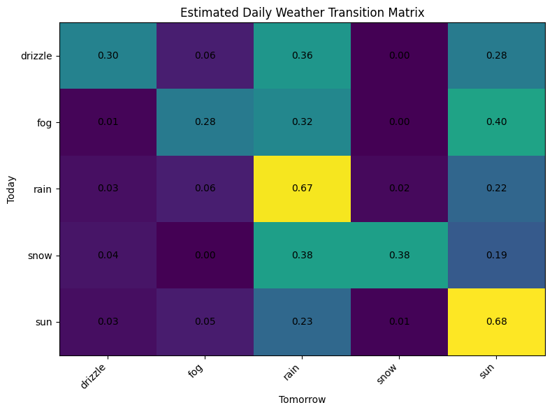

```python
fig, ax = plt.subplots(figsize=(8, 6))
im = ax.imshow(P_hat, aspect="auto")

ax.set_xticks(range(len(all_states)))
ax.set_yticks(range(len(all_states)))
ax.set_xticklabels(all_states, rotation=45, ha="right")
ax.set_yticklabels(all_states)

for i in range(len(all_states)):
    for j in range(len(all_states)):
        ax.text(j, i, f"{P_hat[i, j]:.2f}", ha="center", va="center")

ax.set_xlabel("Tomorrow")
ax.set_ylabel("Today")
ax.set_title("Estimated Daily Weather Transition Matrix")

plt.tight_layout()
plt.show()
```

## Transition graph and communicating classes

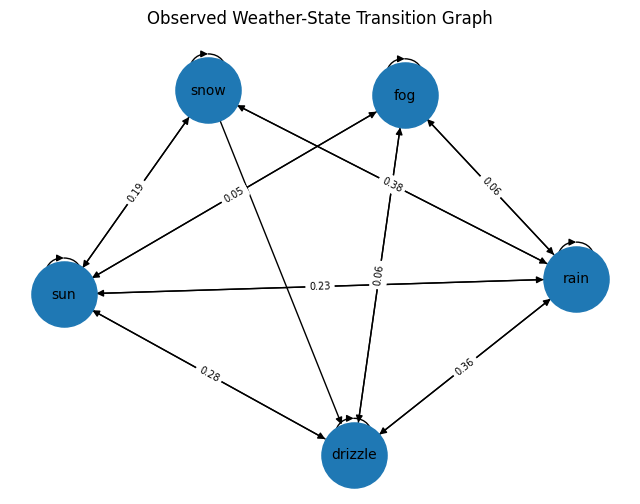

```
[{'drizzle', 'fog', 'rain', 'snow', 'sun'}]
```

```python
weather_graph = nx.DiGraph()

for s in all_states:
    weather_graph.add_node(s)

for i, s1 in enumerate(all_states):
    for j, s2 in enumerate(all_states):
        if P_hat[i, j] > 0:
            weather_graph.add_edge(s1, s2, weight=P_hat[i, j])

plt.figure(figsize=(8, 6))
pos = nx.spring_layout(weather_graph, seed=2)

nx.draw_networkx(
    weather_graph,
    pos,
    node_size=2200,
    arrows=True,
    font_size=10
)

edge_labels = {
    (u, v): f"{d['weight']:.2f}"
    for u, v, d in weather_graph.edges(data=True)
    if d["weight"] >= 0.05
}

nx.draw_networkx_edge_labels(
    weather_graph,
    pos,
    edge_labels=edge_labels,
    font_size=7
)

plt.axis("off")
plt.title("Observed Weather-State Transition Graph")
plt.show()

components = list(nx.strongly_connected_components(weather_graph))
components
```

If all observed weather states belong to one strongly connected component, then the **empirical finite chain is irreducible** on the observed state space.

## Stationary distribution of the empirical weather chain

```python
pi_weather = stationary_distribution(P_hat)

stationary_weather = pd.Series(
    pi_weather,
    index=all_states,
    name="stationary_probability"
)

empirical_weather = (
    weather["weather"]
    .value_counts(normalize=True)
    .reindex(all_states)
)

comparison = pd.concat(
    [
        empirical_weather.rename("empirical_frequency"),
        stationary_weather
    ],
    axis=1
)

comparison["absolute_difference"] = (
    comparison["empirical_frequency"]
    - comparison["stationary_probability"]
).abs()

comparison
```

|  | empirical_frequency | stationary_probability | absolute_difference |
| --- | --- | --- | --- |
| drizzle | 0.0363 | 0.0354 | 9.2292e-04 |
| fog | 0.0691 | 0.0692 | 4.1787e-05 |
| rain | 0.4387 | 0.4388 | 8.6427e-05 |
| snow | 0.0178 | 0.0178 | 2.0952e-05 |
| sun | 0.4381 | 0.4388 | 7.7376e-04 |

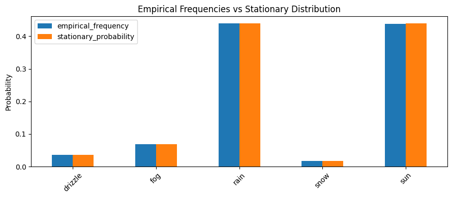

```python
comparison[["empirical_frequency", "stationary_probability"]].plot(
    kind="bar",
    figsize=(9, 4)
)

plt.ylabel("Probability")
plt.title("Empirical Frequencies vs Stationary Distribution")
plt.xticks(rotation=45)
plt.tight_layout()
plt.show()
```

A close match is expected if the process is reasonably stable and the observation period is long enough.

But remember:

> Agreement does **not** prove the Markov assumption.

## (n)-step weather forecasting

For current state (i), row (i) of

[ \hat P^n ]

gives the model's probability distribution (n) days ahead.

```python
def n_step_forecast(P, states, current_state, n):
    idx = states.index(current_state)
    probs = matrix_power(P, n)[idx]
    return pd.Series(probs, index=states, name=f"{n}-step probability")

current_state = "rain"

for horizon in [1, 2, 3, 7, 14]:
    if current_state in all_states:
        display(n_step_forecast(P_hat, all_states, current_state, horizon))
```

```
drizzle    0.0281
fog        0.0562
rain       0.6739
snow       0.0172
sun        0.2246
Name: 1-step probability, dtype: float64
```

```
drizzle    0.0342
fog        0.0670
rain       0.5407
snow       0.0199
sun        0.3382
Name: 2-step probability, dtype: float64
```

```
drizzle    0.0354
fog        0.0689
rain       0.4839
snow       0.0196
sun        0.3923
Name: 3-step probability, dtype: float64
```

```
drizzle    0.0354
fog        0.0692
rain       0.4407
snow       0.0180
sun        0.4368
Name: 7-step probability, dtype: float64
```

```
drizzle    0.0354
fog        0.0692
rain       0.4388
snow       0.0178
sun        0.4388
Name: 14-step probability, dtype: float64
```

## Convergence of weather forecasts toward stationarity

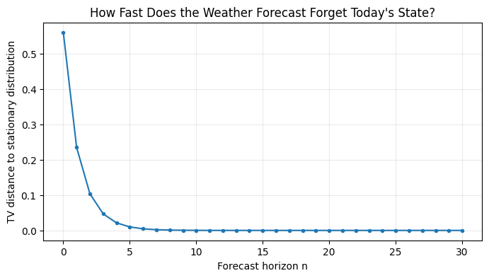

```python
if "rain" in all_states:
    rain_idx = all_states.index("rain")
    mu0 = np.eye(len(all_states))[rain_idx]

    dists = []

    for n in range(31):
        mu_n = mu0 @ matrix_power(P_hat, n)
        dists.append(total_variation(mu_n, pi_weather))

    plt.figure(figsize=(8, 4))
    plt.plot(range(31), dists, marker="o", markersize=3)
    plt.xlabel("Forecast horizon n")
    plt.ylabel("TV distance to stationary distribution")
    plt.title("How Fast Does the Weather Forecast Forget Today's State?")
    plt.grid(alpha=0.25)
    plt.show()
```

## Expected hitting time: how long until a target weather state?

Example target: `snow`.

For every starting state (i),

# [ m_i

1+\sum_j p_{ij}m_j, ]

with

[ m_{\text{snow}}=0. ]

```python
if "snow" in all_states:
    snow_idx = all_states.index("snow")
    snow_hitting = expected_hitting_times(P_hat, snow_idx)

    display(
        pd.Series(
            snow_hitting,
            index=all_states,
            name="Expected days to first hit snow"
        )
    )
```

```
drizzle    91.1951
fog        91.2099
rain       88.9702
snow        0.0000
sun        90.4771
Name: Expected days to first hit snow, dtype: float64
```

The result should be interpreted cautiously.

A homogeneous Markov chain ignores **seasonality**. Snow risk in January and July is obviously not identical.

This is an important modelling lesson:

> A mathematically correct Markov model may still be scientifically misspecified.

## Monte Carlo validation of hitting time

```python
if "snow" in all_states and "rain" in all_states:
    rain_idx = all_states.index("rain")
    snow_idx = all_states.index("snow")

    sim_snow = simulate_hitting_time(
        P_hat,
        start=rain_idx,
        target=snow_idx,
        n_sim=10_000,
        max_steps=10_000,
        rng=RNG
    )

    analytical = expected_hitting_times(P_hat, snow_idx)[rain_idx]

    print("Analytical expected hitting time:", analytical)
    print("Monte Carlo estimate:", sim_snow.mean())
```

```
Analytical expected hitting time: 88.97016007819703
Monte Carlo estimate: 88.4157
```

## Simulating synthetic future weather

We can use the fitted transition matrix as a generative model.

```python
def simulate_labels(P, states, start_state, n_steps, rng=None):
    rng = np.random.default_rng() if rng is None else rng
    start_idx = states.index(start_state)
    path_idx = simulate_markov_chain(P, start_idx, n_steps, rng)
    return [states[i] for i in path_idx]

start_state = weather.iloc[-1]["weather"]

synthetic_future = simulate_labels(
    P_hat,
    all_states,
    start_state=start_state,
    n_steps=30,
    rng=RNG
)

pd.DataFrame({
    "day_ahead": range(31),
    "simulated_weather": synthetic_future
})
```

|  | day_ahead | simulated_weather |
| --- | --- | --- |
| 0 | 0 | sun |
| 1 | 1 | sun |
| 2 | 2 | sun |
| 3 | 3 | sun |
| 4 | 4 | rain |
| 5 | 5 | sun |
| 6 | 6 | sun |
| 7 | 7 | sun |
| 8 | 8 | sun |
| 9 | 9 | sun |
| 10 | 10 | sun |
| 11 | 11 | sun |
| 12 | 12 | fog |
| 13 | 13 | fog |
| 14 | 14 | fog |
| 15 | 15 | rain |
| 16 | 16 | rain |
| 17 | 17 | rain |
| 18 | 18 | rain |
| 19 | 19 | rain |
| 20 | 20 | rain |
| 21 | 21 | rain |
| 22 | 22 | drizzle |
| 23 | 23 | drizzle |
| 24 | 24 | drizzle |
| 25 | 25 | rain |
| 26 | 26 | rain |
| 27 | 27 | rain |
| 28 | 28 | rain |
| 29 | 29 | rain |
| 30 | 30 | drizzle |

# 12. Testing the First-Order Markov Assumption Empirically

The first-order Markov property claims

# [ P(X_{t+1}\mid X_t,X_{t-1},\ldots)

P(X_{t+1}\mid X_t). ]

One empirical diagnostic is to compare

[ P(X_{t+1}=j\mid X_t=i) ]

against

[ P(X_{t+1}=j\mid X_t=i,X_{t-1}=k). ]

If the previous state (X_{t-1}) strongly changes the next-state probabilities even after conditioning on (X_t), a first-order Markov approximation may be inadequate.

```python
weather_markov = weather[["date", "weather"]].copy()

weather_markov["prev_weather"] = weather_markov["weather"].shift(1)
weather_markov["next_weather"] = weather_markov["weather"].shift(-1)

weather_markov = weather_markov.dropna().copy()

triplet_counts = (
    weather_markov
    .groupby(["prev_weather", "weather", "next_weather"])
    .size()
    .rename("count")
    .reset_index()
)

triplet_counts.head()
```

|  | prev_weather | weather | next_weather | count |
| --- | --- | --- | --- | --- |
| 0 | drizzle | drizzle | drizzle | 8 |
| 1 | drizzle | drizzle | rain | 4 |
| 2 | drizzle | drizzle | sun | 4 |
| 3 | drizzle | fog | drizzle | 1 |
| 4 | drizzle | fog | rain | 1 |

Let's examine a current state with substantial support, such as `rain`, and compare tomorrow's distribution depending on yesterday.

```python
current = "rain"

if current in all_states:
    subset = weather_markov[weather_markov["weather"] == current]

    conditional_second_order = pd.crosstab(
        subset["prev_weather"],
        subset["next_weather"],
        normalize="index"
    ).reindex(columns=all_states, fill_value=0)

    display(conditional_second_order.round(3))
```

| next_weather prev_weather | drizzle | fog | rain | snow | sun |
| --- | --- | --- | --- | --- | --- |
| drizzle | 0.000 | 0.105 | 0.789 | 0.000 | 0.105 |
| fog | 0.031 | 0.125 | 0.656 | 0.000 | 0.188 |
| rain | 0.032 | 0.051 | 0.676 | 0.019 | 0.222 |
| snow | 0.000 | 0.000 | 0.600 | 0.300 | 0.100 |
| sun | 0.020 | 0.054 | 0.662 | 0.000 | 0.264 |

Large row-to-row differences suggest that a richer model could be useful, such as:

- a second-order Markov chain,
- a seasonal Markov chain,
- hidden Markov models,
- covariate-dependent transition models,
- dynamic Bayesian models.

This is where stochastic-process theory connects directly to modern statistical modelling.

# 13. Seasonal Markov Chains

Seattle weather is strongly seasonal.

Instead of assuming one fixed transition matrix (P), we can estimate

[ P^{(\text{season})}. ]

This creates a **time-inhomogeneous / regime-dependent** extension of the basic homogeneous DTMC.

```python
def month_to_season(month):
    if month in [12, 1, 2]:
        return "winter"
    if month in [3, 4, 5]:
        return "spring"
    if month in [6, 7, 8]:
        return "summer"
    return "autumn"

weather["season"] = weather["date"].dt.month.map(month_to_season)

weather["next_weather"] = weather["weather"].shift(-1)
weather["next_date"] = weather["date"].shift(-1)
weather["day_gap"] = (weather["next_date"] - weather["date"]).dt.days

season_transitions = weather[
    (weather["day_gap"] == 1)
    & weather["next_weather"].notna()
].copy()

season_transition_matrices = {}

for season, grp in season_transitions.groupby("season"):
    counts = pd.crosstab(grp["weather"], grp["next_weather"])
    counts = counts.reindex(
        index=all_states,
        columns=all_states,
        fill_value=0
    )

    matrix = counts.div(counts.sum(axis=1).replace(0, np.nan), axis=0)
    season_transition_matrices[season] = matrix

for season, matrix in season_transition_matrices.items():
    print("\n", season.upper())
    display(matrix.round(3))
```

```
 AUTUMN
```

| next_weather weather | drizzle | fog | rain | snow | sun |
| --- | --- | --- | --- | --- | --- |
| drizzle | 0.417 | 0.083 | 0.500 | 0.000 | 0.000 |
| fog | 0.000 | 0.357 | 0.310 | 0.000 | 0.333 |
| rain | 0.017 | 0.064 | 0.717 | 0.006 | 0.197 |
| snow | 0.000 | 0.000 | 0.000 | 0.000 | 1.000 |
| sun | 0.029 | 0.110 | 0.235 | 0.000 | 0.625 |

```
 SPRING
```

| next_weather weather | drizzle | fog | rain | snow | sun |
| --- | --- | --- | --- | --- | --- |
| drizzle | 0.000 | 0.143 | 0.429 | 0.000 | 0.429 |
| fog | 0.000 | 0.214 | 0.500 | 0.000 | 0.286 |
| rain | 0.034 | 0.034 | 0.626 | 0.029 | 0.276 |
| snow | 0.000 | 0.000 | 0.571 | 0.143 | 0.286 |
| sun | 0.006 | 0.024 | 0.307 | 0.006 | 0.657 |

```
 SUMMER
```

| next_weather weather | drizzle | fog | rain | snow | sun |
| --- | --- | --- | --- | --- | --- |
| drizzle | 0.222 | 0.056 | 0.167 | 0.0 | 0.556 |
| fog | 0.059 | 0.059 | 0.059 | 0.0 | 0.824 |
| rain | 0.037 | 0.049 | 0.488 | 0.0 | 0.427 |
| snow | NaN | NaN | NaN | NaN | NaN |
| sun | 0.040 | 0.044 | 0.147 | 0.0 | 0.769 |

```
 WINTER
```

| next_weather weather | drizzle | fog | rain | snow | sun |
| --- | --- | --- | --- | --- | --- |
| drizzle | 0.438 | 0.000 | 0.438 | 0.000 | 0.125 |
| fog | 0.000 | 0.321 | 0.393 | 0.000 | 0.286 |
| rain | 0.028 | 0.071 | 0.750 | 0.024 | 0.127 |
| snow | 0.056 | 0.000 | 0.333 | 0.500 | 0.111 |
| sun | 0.012 | 0.047 | 0.326 | 0.047 | 0.570 |

This demonstrates an important modelling principle:

[ \text{simple homogeneous chain} \quad\longrightarrow\quad \text{state + context dependent transition model}. ]

The theoretical ST3236 concepts remain the foundation.

# 14. Mini Exercises

Try these before revealing your own solution.

### Exercise 1

For the synthetic 3-state chain, calculate

[ P(X_4=\text{Rainy}\mid X_0=\text{Cloudy}). ]

### Exercise 2

Find the stationary distribution manually by solving

[ \pi P=\pi,\qquad \sum_i\pi_i=1. ]

### Exercise 3

Using the weather dataset, identify the most persistent state:

[ \arg\max_i \hat p_{ii}. ]

### Exercise 4

For each state, compute expected time to first hit `rain`.

### Exercise 5

Compare the one-step empirical distribution conditioned on:

[ X_t=\text{rain} ]

against

[ X_t=\text{rain},\quad X_{t-1}=\text{sun}. ]

### Exercise 6

Estimate separate winter and summer stationary distributions.

### Exercise 7

Construct a two-state chain:

- wet = rain / drizzle / snow,
- dry = sun / fog,

and repeat the full analysis.

### Exercise 8

Simulate 10,000 synthetic years and compare simulated weather-state frequencies with (\pi).

# 15. ST3236 Concept Map

[ \boxed{ \text{Stochastic Process} \to \text{Markov Property} \to P \to P^n \to \text{Communication Classes} \to \text{Recurrence / Transience} \to \text{Hitting Times} \to \pi \to \text{Convergence / Ergodicity} } ]

Extensions:

[ \text{Markov Chains} \to \begin{cases} \text{Random Walks}\\ \text{Absorbing Chains}\\ \text{Queueing Models}\\ \text{Hidden Markov Models}\\ \text{MCMC}\\ \text{Markov Decision Processes}\\ \text{Reinforcement Learning} \end{cases} ]

and

[ \text{Continuous-Time Counting} \to \text{Poisson Process} \to \text{Exponential Waiting Times}. ]

These ideas form a mathematical foundation for much of probability, statistical modelling, operations research, reliability engineering, Bayesian computation, and reinforcement learning.

# 16. Complexity Notes for the Computational Methods

For a chain with (S) states:

### One-step simulation

Sampling from a dense categorical row costs approximately

[ O(S) ]

with a straightforward implementation.

### Computing (P^n)

Naive repeated multiplication:

[ O(nS^3). ]

Exponentiation by squaring / optimized matrix power:

[ O(S^3\log n) ]

under classical dense matrix multiplication.

### Stationary distribution through eigendecomposition

Approximately

[ O(S^3) ]

for a dense matrix.

### Hitting times via a linear system

Solving

[ (I-Q)m=\mathbf 1 ]

costs approximately

[ O(S^3) ]

for dense direct solvers.

### Sparse chains

For very large state spaces, sparse matrices and iterative solvers can reduce memory and computational cost dramatically.

This becomes important in:

- PageRank,
- web-scale random walks,
- recommendation systems,
- large MDPs,
- graph analytics.

# End of Notebook

You should now be able to move between three views of a stochastic process:

1. **Probabilistic:** conditional probabilities and random variables.
2. **Linear-algebraic:** transition matrices, powers, eigenvectors.
3. **Simulation-based:** sample paths and Monte Carlo verification.

A strong ST3236 understanding comes from being fluent in all three.